# Cross integration — a complete walkthrough

**Cross integration** has several batches in which **all** modalities are present. The task is removing batch effects while keeping biological structure. (Spatial registration also lives under `cross` — see the note at the end.)

**Reference dataset:** `D52` (23,478 cells) — **8 methods** apply to it. Every one has a row in the results table below: scored, failed, or explicitly marked as verified on another dataset. None disappears silently.

Everything below uses the same three calls, whatever the scenario:

```
mtb.scan(dataset)                    # what can I run?
res = mtb.run_all(dataset, category) # run it, with metrics
res.plot()                           # one figure
```

```python
import warnings; warnings.filterwarnings("ignore")
%matplotlib inline
from pathlib import Path
import pandas as pd
pd.set_option("display.max_colwidth", None)  # show `reason` in full - paths are long
import multibench as mtb

RESULTS = Path("results")          # stored results, so the comparisons reproduce
print("multibench", mtb.__version__)
```

```
multibench 0.1.0
```

```python
DATASET  = "D52"
CATEGORY = "cross"
FAST_METHOD = "StabMap"        # used for the quick live demos below
```

## 0. Which scenario is my data, and how do I lay it out?

Two calls answer what every new user hits first. `category` is a required argument everywhere, so start by seeing the legal values:

```python
mtb.list_categories()
```

```
{'vertical': 'Several modalities measured in the SAME cells (e.g. CITE-seq RNA+ADT, or 10x multiome RNA+ATAC). Cells are already matched.',
 'diagonal': 'Modalities measured in DIFFERENT cells, with no pairing (e.g. an RNA experiment and a separate ATAC experiment).',
 'mosaic': 'Several batches where only SOME share a modality; a paired batch bridges the others.',
 'cross': 'Several batches in which ALL modalities are present; the task is removing batch effects. (Spatial slice registration also lives here.)'}
```

And this prints exactly which filenames to use — including how **several batches** are named (numbered files in one flat directory):

```python
print(mtb.describe_layout(CATEGORY))
```

```
Put your files in  <data_path>/<DATASET_NAME>/ , e.g. ./data/MYDATA/
  (dataset = the folder NAME; data_path = the folder that CONTAINS it)

LAYOUT FOR CROSS:
  rna1.h5 rna2.h5 rna3.h5 + adt1.h5 adt2.h5 adt3.h5
  cty1.csv cty2.csv cty3.csv          <- one per batch
  (spatial registration instead takes a directory of .h5ad slices)

  (numbered files live in the SAME flat dir; there is no batch column)

Modality roles and the filenames they resolve to:
    rna              rna.h5      - gene expression
    adt              adt.h5      - surface protein (CITE-seq antibody-derived tags)
    atac             atac.h5     - chromatin accessibility
    atac_gas         atac.h5     - ATAC as GENE-ACTIVITY scores  <-- note: plain atac.h5
    atac_peak        peak.h5     - ATAC as PEAKS                 <-- note: peak.h5, NOT atac.h5
    rna1/rna2/...    rna1.h5, rna2.h5, ... - one file per BATCH (mosaic/cross)
    adt1/adt2/...    adt1.h5, adt2.h5, ... - one file per BATCH (mosaic/cross)
    cty              cty.csv     - cell-type labels, ONE label set (vertical)
    rna_cty / atac_cty rna_cty.csv, atac_cty.csv - one label file PER MODALITY, used when RNA and ATAC come from different cells (diagonal)
    cty1/cty2/...    cty1.csv, cty2.csv, ... - one label file per BATCH (mosaic/cross)

!! Careful: the two ATAC representations do NOT map to the obvious names.
   gene-activity -> atac.h5   and   peaks -> peak.h5 .
   Putting a peak matrix in atac.h5 runs every method on the wrong
   representation without any error.

Modality files are HDF5 with the matrix under 'matrix/data'.
Use mtb.io.to_canonical(src, dst) to convert another layout.
Labels are CSV with one row per cell; the last column (or a column
named 'x') holds the cell type.

cross: Several batches in which ALL modalities are present; the task is removing batch effects. (Spatial slice registration also lives here.)


ENVIRONMENTS
  Every method runs in its OWN conda env (they need mutually
  incompatible framework versions). scan() marks a method NOT runnable
  if its env is missing, so a sweep never starts one that cannot finish.
      multibench env doctor          # what is needed / what is missing
      multibench env install --run   # build them all from lockfiles

Then:  mtb.scan('MYDATA')  ->  mtb.run_all('MYDATA', '<category>', out_dir=...)
```

## 1. What can I run on this data?

`scan` inspects the dataset and reports every method that can run — and, for the rest, exactly why not. Nothing is executed, so this is safe and instant.

```python
avail = mtb.scan(DATASET, category=CATEGORY)
avail[avail.runnable][["method", "modalities", "env", "output_kind",
                       "n_tunable", "runtime_tier", "observed_worst_sec"]]
```

|  | method | modalities | env | output_kind | n_tunable | runtime_tier | observed_worst_sec |
| --- | --- | --- | --- | --- | --- | --- | --- |
| 0 | Concerto | rna1+rna2+rna3+adt1+adt2+adt3 | scmb_concerto | embedding | 0 | very_slow | 8798 |
| 1 | StabMap | rna1+rna2+rna3+adt1+adt2+adt3 | scmb_r | embedding | 0 | fast | 69 |
| 2 | UINMF | rna1+rna2+adt1+adt2 | scmb_r | embedding | 0 | fast | 262 |
| 3 | scMDC | rna1+rna2+rna3+adt1+adt2+adt3 | scmb_scmdc | embedding | 0 | slow | 2702 |
| 4 | scMM | rna1+rna2+rna3+adt1+adt2+adt3 | scmb_scmm2 | embedding | 0 | medium | 628 |
| 5 | scMoMaT | rna1+rna2+rna3+adt1+adt2+adt3 | scmb_torch | graph | 0 | medium | 1023 |
| 6 | sciPENN | rna1+rna2+rna3+adt1+adt2+adt3 | env_sciPENN | embedding | 0 | fast | 144 |
| 7 | totalVI | rna1+rna2+rna3+adt1+adt2+adt3 | scmb_scvi | embedding | 0 | slow | 2840 |

Methods that are *not* runnable here come with a reason rather than a silent absence:

```python
not_ok = avail[~avail.runnable][["method", "modalities", "reason"]]
not_ok.head(5) if len(not_ok) else "(everything in this category runs on this dataset)"
```

|  | method | modalities | reason |
| --- | --- | --- | --- |
| 8 | GPSA | (data_dir) | spatial registration needs >=2 .h5ad slice files; found 0 in /media/disk2/Sichang/scmbench_pkg/data/D52 |
| 9 | PASTE | (data_dir) | spatial registration needs >=2 .h5ad slice files; found 0 in /media/disk2/Sichang/scmbench_pkg/data/D52 |
| 10 | PASTE2 | (data_dir) | spatial registration needs >=2 .h5ad slice files; found 0 in /media/disk2/Sichang/scmbench_pkg/data/D52 |
| 11 | SPIRAL | (data_dir) | spatial registration needs >=2 .h5ad slice files; found 0 in /media/disk2/Sichang/scmbench_pkg/data/D52 |

## 2. What can I tune?

`params_for` reports the parameters a method accepts. `defaults` are what the wrapper passes; `tunable` is what the **upstream script** exposes on its command line. An empty `tunable` means that method hardcodes its hyperparameters — it cannot be tuned without editing it, which this project never does.

```python
rows = []
for m in avail[avail.runnable]["method"]:
    p = mtb.params_for(m, CATEGORY, None if avail[avail.method==m].iloc[0]["modalities"]=="(data_dir)"
                       else avail[avail.method==m].iloc[0]["modalities"].split("+"))
    rows.append({"method": m, "n_tunable": len(p["tunable"]),
                 "defaults": p["defaults"],
                 "example": ", ".join(sorted(p["tunable"])[:4]) or "(hardcoded upstream)"})
pd.DataFrame(rows).sort_values("n_tunable", ascending=False).reset_index(drop=True)
```

|  | method | n_tunable | defaults | example |
| --- | --- | --- | --- | --- |
| 0 | Concerto | 0 | {} | (hardcoded upstream) |
| 1 | StabMap | 0 | {} | (hardcoded upstream) |
| 2 | UINMF | 0 | {} | (hardcoded upstream) |
| 3 | scMDC | 0 | {'nbatch': 3} | (hardcoded upstream) |
| 4 | scMM | 0 | {'model': 'rna_protein', 'no_cuda': True} | (hardcoded upstream) |
| 5 | scMoMaT | 0 | {} | (hardcoded upstream) |
| 6 | sciPENN | 0 | {} | (hardcoded upstream) |
| 7 | totalVI | 0 | {} | (hardcoded upstream) |

## 3. Run one method

StabMap finishes in ~70 s. Tuning happens through `params=` — the same parameters `params_for` just listed.

```python
res = mtb.run_all(DATASET, CATEGORY,
                  methods=["StabMap"],
                  out_dir="/tmp/tutorial_cross")
res
```

```
[run_all] StabMap (cross/D52) ...
```

```
Cluster for cluster_0.2 with leiden
```

```
Cluster for cluster_0.4 with leiden
```

```
Cluster for cluster_0.6 with leiden
```

```
Cluster for cluster_0.8 with leiden
```

```
Cluster for cluster_1.0 with leiden
```

```
Cluster for cluster_1.2 with leiden
```

```
Cluster for cluster_1.4 with leiden
```

```
Cluster for cluster_1.6 with leiden
```

```
Cluster for cluster_1.8 with leiden
```

```
Cluster for cluster_2.0 with leiden
```

```
isolated labels: no more than 1 batches per label
isolated labels: ['Erythroid ', 'Platelet-T cell doublets']
```

```
Erythroid : 0.4686116950200608
Platelet-T cell doublets: 0.42371761411757924
isolated labels: no more than 1 batches per label
isolated labels: ['Erythroid ', 'Platelet-T cell doublets']
Cluster for iso_label_0.2 with leiden
```

```
resolution: 0.2, max_f1: 0.007352941176470588
```

```
Cluster for iso_label_0.4 with leiden
```

```
resolution: 0.4, max_f1: 0.01694915254237288
```

```
Cluster for iso_label_0.6 with leiden
```

```
resolution: 0.6, max_f1: 0.01694915254237288
```

```
Cluster for iso_label_0.8 with leiden
```

```
resolution: 0.8, max_f1: 0.016260162601626018
```

```
Cluster for iso_label_1.0 with leiden
```

```
resolution: 1.0, max_f1: 0.016260162601626018
```

```
Cluster for iso_label_1.2 with leiden
```

```
resolution: 1.2, max_f1: 0.016129032258064516
```

```
Cluster for iso_label_1.4 with leiden
```

```
resolution: 1.4, max_f1: 0.014084507042253521
```

```
Cluster for iso_label_1.6 with leiden
```

```
resolution: 1.6, max_f1: 0.016
```

```
Cluster for iso_label_1.8 with leiden
```

```
resolution: 1.8, max_f1: 0.016129032258064516
```

```
Cluster for iso_label_2.0 with leiden
```

```
resolution: 2.0, max_f1: 0.016
```

```
optimised clustering against celltype
optimal cluster resolution: 0.4
optimal score: 0.01694915254237288
Erythroid : 0.01694915254237288
Cluster for iso_label_0.2 with leiden
```

```
resolution: 0.2, max_f1: 0.004464285714285714
```

```
Cluster for iso_label_0.4 with leiden
```

```
resolution: 0.4, max_f1: 0.004431314623338257
```

```
Cluster for iso_label_0.6 with leiden
```

```
resolution: 0.6, max_f1: 0.010498687664041995
```

```
Cluster for iso_label_0.8 with leiden
```

```
resolution: 0.8, max_f1: 0.010443864229765013
```

```
Cluster for iso_label_1.0 with leiden
```

```
resolution: 1.0, max_f1: 0.00975609756097561
```

```
Cluster for iso_label_1.2 with leiden
```

```
resolution: 1.2, max_f1: 0.009523809523809525
```

```
Cluster for iso_label_1.4 with leiden
```

```
resolution: 1.4, max_f1: 0.010666666666666666
```

```
Cluster for iso_label_1.6 with leiden
```

```
resolution: 1.6, max_f1: 0.009478672985781991
```

```
Cluster for iso_label_1.8 with leiden
```

```
resolution: 1.8, max_f1: 0.01098901098901099
```

```
Cluster for iso_label_2.0 with leiden
```

```
resolution: 2.0, max_f1: 0.009478672985781991
```

```
optimised clustering against celltype
optimal cluster resolution: 1.8
optimal score: 0.01098901098901099
Platelet-T cell doublets: 0.01098901098901099
```

[output not shown]

```
mean silhouette per group:                               silhouette_score
group
CD4 and CD8 activated memory          0.907079
CD4 memory                            0.957714
CD4 naive I                           0.968965
CD4 naive II                          0.960287
CD56bright CD16dim NK                 0.944973
CD56dim CD16bright NK                 0.972344
CD8 effector                          0.953907
CD8 memory                            0.950640
CD8 naive                             0.939041
Classical monocytes                   0.965648
MAIT-NKT cells                        0.968113
Memory B                              0.979989
NK-T doublets                         0.935411
NK-monocyte doublets                  0.984474
Naive B                               0.963116
Neutrophils                           0.972955
Non classical monocytes               0.962299
Plasma cells                          0.808358
Platelet-bound monocytes              0.969039
Platelets                             0.949372
Proliferating T and NK cell           0.903439
Regulatory T cells                    0.969622
T-NK-B cell doublets                  0.966202
conventional DC                       0.946368
gdT cells                             0.927435
plasmacytoid DC                       0.951601
```

[output not shown]

[output cut: 19 more lines]

[output not shown]

```
Cluster for cluster_0.2 with leiden
```

```
Cluster for cluster_0.4 with leiden
```

```
Cluster for cluster_0.6 with leiden
```

```
Cluster for cluster_0.8 with leiden
```

```
Cluster for cluster_1.0 with leiden
```

```
Cluster for cluster_1.2 with leiden
```

```
Cluster for cluster_1.4 with leiden
```

```
Cluster for cluster_1.6 with leiden
```

```
Cluster for cluster_1.8 with leiden
```

```
Cluster for cluster_2.0 with leiden
```

```
isolated labels: no more than 1 batches per label
isolated labels: ['Erythroid ', 'Platelet-T cell doublets']
```

```
Erythroid : 0.422660472854008
Platelet-T cell doublets: 0.41479743336366093
isolated labels: no more than 1 batches per label
isolated labels: ['Erythroid ', 'Platelet-T cell doublets']
Cluster for iso_label_0.2 with leiden
```

```
resolution: 0.2, max_f1: 0.00564652738565782
```

```
Cluster for iso_label_0.4 with leiden
```

```
resolution: 0.4, max_f1: 0.025974025974025976
```

```
Cluster for iso_label_0.6 with leiden
```

```
resolution: 0.6, max_f1: 0.025974025974025976
```

```
Cluster for iso_label_0.8 with leiden
```

```
resolution: 0.8, max_f1: 0.025974025974025976
```

```
Cluster for iso_label_1.0 with leiden
```

```
resolution: 1.0, max_f1: 0.025974025974025976
```

```
Cluster for iso_label_1.2 with leiden
```

```
resolution: 1.2, max_f1: 0.025974025974025976
```

```
Cluster for iso_label_1.4 with leiden
```

```
resolution: 1.4, max_f1: 0.025974025974025976
```

```
Cluster for iso_label_1.6 with leiden
```

```
resolution: 1.6, max_f1: 0.025974025974025976
```

```
Cluster for iso_label_1.8 with leiden
```

```
resolution: 1.8, max_f1: 0.025974025974025976
```

```
Cluster for iso_label_2.0 with leiden
```

```
resolution: 2.0, max_f1: 0.025974025974025976
```

```
optimised clustering against celltype
optimal cluster resolution: 0.4
optimal score: 0.025974025974025976
Erythroid : 0.025974025974025976
Cluster for iso_label_0.2 with leiden
```

```
resolution: 0.2, max_f1: 0.004884004884004884
```

```
Cluster for iso_label_0.4 with leiden
```

```
resolution: 0.4, max_f1: 0.0048721071863581
```

```
Cluster for iso_label_0.6 with leiden
```

```
resolution: 0.6, max_f1: 0.005249343832020997
```

```
Cluster for iso_label_0.8 with leiden
```

```
resolution: 0.8, max_f1: 0.005221932114882507
```

```
Cluster for iso_label_1.0 with leiden
```

```
resolution: 1.0, max_f1: 0.007722007722007722
```

```
Cluster for iso_label_1.2 with leiden
```

```
resolution: 1.2, max_f1: 0.004914004914004914
```

```
Cluster for iso_label_1.4 with leiden
```

```
resolution: 1.4, max_f1: 0.007407407407407408
```

```
Cluster for iso_label_1.6 with leiden
```

```
resolution: 1.6, max_f1: 0.0049079754601227
```

```
Cluster for iso_label_1.8 with leiden
```

```
resolution: 1.8, max_f1: 0.007782101167315175
```

```
Cluster for iso_label_2.0 with leiden
```

```
resolution: 2.0, max_f1: 0.007633587786259542
```

```
optimised clustering against celltype
optimal cluster resolution: 1.8
optimal score: 0.007782101167315175
Platelet-T cell doublets: 0.007782101167315175
```

[output not shown]

```
mean silhouette per group:                               silhouette_score
group
CD4 and CD8 activated memory          0.759050
CD4 memory                            0.683456
CD4 naive I                           0.653153
CD4 naive II                          0.693231
CD56bright CD16dim NK                 0.803790
CD56dim CD16bright NK                 0.815708
CD8 effector                          0.763877
CD8 memory                            0.720740
CD8 naive                             0.682269
Classical monocytes                   0.841938
MAIT-NKT cells                        0.615209
Memory B                              0.739828
NK-T doublets                         0.798680
NK-monocyte doublets                  0.951967
Naive B                               0.813908
Neutrophils                           0.855255
Non classical monocytes               0.827786
Plasma cells                          0.914288
Platelet-bound monocytes              0.864066
Platelets                             0.701778
Proliferating T and NK cell           0.956924
Regulatory T cells                    0.701787
T-NK-B cell doublets                  0.847369
conventional DC                       0.847283
gdT cells                             0.796788
plasmacytoid DC                       0.769029
```

[output not shown]

[output cut: 19 more lines]

[output not shown]

```
Cluster for cluster_0.2 with leiden
```

```
Cluster for cluster_0.4 with leiden
```

```
Cluster for cluster_0.6 with leiden
```

```
Cluster for cluster_0.8 with leiden
```

```
Cluster for cluster_1.0 with leiden
```

```
Cluster for cluster_1.2 with leiden
```

```
Cluster for cluster_1.4 with leiden
```

```
Cluster for cluster_1.6 with leiden
```

```
Cluster for cluster_1.8 with leiden
```

```
Cluster for cluster_2.0 with leiden
```

```
isolated labels: no more than 1 batches per label
isolated labels: ['Erythroid ', 'Platelet-T cell doublets']
```

```
Erythroid : 0.46137915749568403
Platelet-T cell doublets: 0.41795332022174014
isolated labels: no more than 1 batches per label
isolated labels: ['Erythroid ', 'Platelet-T cell doublets']
Cluster for iso_label_0.2 with leiden
```

```
resolution: 0.2, max_f1: 0.007352941176470588
```

```
Cluster for iso_label_0.4 with leiden
```

```
resolution: 0.4, max_f1: 0.01694915254237288
```

```
Cluster for iso_label_0.6 with leiden
```

```
resolution: 0.6, max_f1: 0.01694915254237288
```

```
Cluster for iso_label_0.8 with leiden
```

```
resolution: 0.8, max_f1: 0.016260162601626018
```

```
Cluster for iso_label_1.0 with leiden
```

```
resolution: 1.0, max_f1: 0.016260162601626018
```

```
Cluster for iso_label_1.2 with leiden
```

```
resolution: 1.2, max_f1: 0.016129032258064516
```

```
Cluster for iso_label_1.4 with leiden
```

```
resolution: 1.4, max_f1: 0.014084507042253521
```

```
Cluster for iso_label_1.6 with leiden
```

```
resolution: 1.6, max_f1: 0.016
```

```
Cluster for iso_label_1.8 with leiden
```

```
resolution: 1.8, max_f1: 0.016129032258064516
```

```
Cluster for iso_label_2.0 with leiden
```

```
resolution: 2.0, max_f1: 0.016
```

```
optimised clustering against celltype
optimal cluster resolution: 0.4
optimal score: 0.01694915254237288
Erythroid : 0.01694915254237288
Cluster for iso_label_0.2 with leiden
```

```
resolution: 0.2, max_f1: 0.004464285714285714
```

```
Cluster for iso_label_0.4 with leiden
```

```
resolution: 0.4, max_f1: 0.004431314623338257
```

```
Cluster for iso_label_0.6 with leiden
```

```
resolution: 0.6, max_f1: 0.010498687664041995
```

```
Cluster for iso_label_0.8 with leiden
```

```
resolution: 0.8, max_f1: 0.010443864229765013
```

```
Cluster for iso_label_1.0 with leiden
```

```
resolution: 1.0, max_f1: 0.00975609756097561
```

```
Cluster for iso_label_1.2 with leiden
```

```
resolution: 1.2, max_f1: 0.009523809523809525
```

```
Cluster for iso_label_1.4 with leiden
```

```
resolution: 1.4, max_f1: 0.010666666666666666
```

```
Cluster for iso_label_1.6 with leiden
```

```
resolution: 1.6, max_f1: 0.009478672985781991
```

```
Cluster for iso_label_1.8 with leiden
```

```
resolution: 1.8, max_f1: 0.01098901098901099
```

```
Cluster for iso_label_2.0 with leiden
```

```
resolution: 2.0, max_f1: 0.009478672985781991
```

```
optimised clustering against celltype
optimal cluster resolution: 1.8
optimal score: 0.01098901098901099
Platelet-T cell doublets: 0.01098901098901099
```

[output not shown]

```
mean silhouette per group:                               silhouette_score
group
CD4 and CD8 activated memory          0.935401
CD4 memory                            0.969699
CD4 naive I                           0.965742
CD4 naive II                          0.963407
CD56bright CD16dim NK                 0.936292
CD56dim CD16bright NK                 0.958411
CD8 effector                          0.975722
CD8 memory                            0.928902
CD8 naive                             0.930186
Classical monocytes                   0.979282
MAIT-NKT cells                        0.964168
Memory B                              0.943195
NK-T doublets                         0.981267
NK-monocyte doublets                  0.872282
Naive B                               0.964504
Neutrophils                           0.907220
Non classical monocytes               0.955957
Plasma cells                          0.823780
Platelet-bound monocytes              0.924784
Platelets                             0.946853
Proliferating T and NK cell           0.963418
Regulatory T cells                    0.962064
T-NK-B cell doublets                  0.954085
conventional DC                       0.961908
gdT cells                             0.966675
plasmacytoid DC                       0.962105
```

[output not shown]

[output cut: 19 more lines]

[output not shown]

```
Cluster for cluster_0.2 with leiden
```

```
Cluster for cluster_0.4 with leiden
```

```
Cluster for cluster_0.6 with leiden
```

```
Cluster for cluster_0.8 with leiden
```

```
Cluster for cluster_1.0 with leiden
```

```
Cluster for cluster_1.2 with leiden
```

```
Cluster for cluster_1.4 with leiden
```

```
Cluster for cluster_1.6 with leiden
```

```
Cluster for cluster_1.8 with leiden
```

```
Cluster for cluster_2.0 with leiden
```

```
isolated labels: no more than 1 batches per label
isolated labels: ['Erythroid ', 'Platelet-T cell doublets']
```

```
Erythroid : 0.494669847221645
Platelet-T cell doublets: 0.47696322633466837
isolated labels: no more than 1 batches per label
isolated labels: ['Erythroid ', 'Platelet-T cell doublets']
Cluster for iso_label_0.2 with leiden
```

```
resolution: 0.2, max_f1: 0.005925925925925926
```

```
Cluster for iso_label_0.4 with leiden
```

```
resolution: 0.4, max_f1: 0.01694915254237288
```

```
Cluster for iso_label_0.6 with leiden
```

```
resolution: 0.6, max_f1: 0.01694915254237288
```

```
Cluster for iso_label_0.8 with leiden
```

```
resolution: 0.8, max_f1: 0.016260162601626018
```

```
Cluster for iso_label_1.0 with leiden
```

```
resolution: 1.0, max_f1: 0.01818181818181818
```

```
Cluster for iso_label_1.2 with leiden
```

```
resolution: 1.2, max_f1: 0.01818181818181818
```

```
Cluster for iso_label_1.4 with leiden
```

```
resolution: 1.4, max_f1: 0.014084507042253521
```

```
Cluster for iso_label_1.6 with leiden
```

```
resolution: 1.6, max_f1: 0.01904761904761905
```

```
Cluster for iso_label_1.8 with leiden
```

```
resolution: 1.8, max_f1: 0.01904761904761905
```

```
Cluster for iso_label_2.0 with leiden
```

```
resolution: 2.0, max_f1: 0.018518518518518517
```

```
optimised clustering against celltype
optimal cluster resolution: 1.6
optimal score: 0.01904761904761905
Erythroid : 0.01904761904761905
Cluster for iso_label_0.2 with leiden
```

```
resolution: 0.2, max_f1: 0.00273224043715847
```

```
Cluster for iso_label_0.4 with leiden
```

```
resolution: 0.4, max_f1: 0.012121212121212121
```

```
Cluster for iso_label_0.6 with leiden
```

```
resolution: 0.6, max_f1: 0.005633802816901409
```

```
Cluster for iso_label_0.8 with leiden
```

```
resolution: 0.8, max_f1: 0.012121212121212121
```

```
Cluster for iso_label_1.0 with leiden
```

```
resolution: 1.0, max_f1: 0.006896551724137931
```

```
Cluster for iso_label_1.2 with leiden
```

```
resolution: 1.2, max_f1: 0.0076045627376425855
```

```
Cluster for iso_label_1.4 with leiden
```

```
resolution: 1.4, max_f1: 0.007407407407407408
```

```
Cluster for iso_label_1.6 with leiden
```

```
resolution: 1.6, max_f1: 0.00749063670411985
```

```
Cluster for iso_label_1.8 with leiden
```

```
resolution: 1.8, max_f1: 0.012048192771084338
```

```
Cluster for iso_label_2.0 with leiden
```

```
resolution: 2.0, max_f1: 0.013888888888888888
```

```
optimised clustering against celltype
optimal cluster resolution: 2.0
optimal score: 0.013888888888888888
Platelet-T cell doublets: 0.013888888888888888
```

[output not shown]

```
mean silhouette per group:                               silhouette_score
group
CD4 and CD8 activated memory          0.861841
CD4 memory                            0.970855
CD4 naive I                           0.964445
CD4 naive II                          0.968295
CD56bright CD16dim NK                 0.942002
CD56dim CD16bright NK                 0.983591
CD8 effector                          0.955109
CD8 memory                            0.958292
CD8 naive                             0.955512
Classical monocytes                   0.988849
MAIT-NKT cells                        0.942298
Memory B                              0.911684
NK-T doublets                         0.939926
NK-monocyte doublets                  0.928712
Naive B                               0.970917
Neutrophils                           0.903532
Non classical monocytes               0.982324
Plasma cells                          0.919268
Platelet-bound monocytes              0.924936
Platelets                             0.888918
Proliferating T and NK cell           0.956413
Regulatory T cells                    0.866305
T-NK-B cell doublets                  0.967742
conventional DC                       0.949222
gdT cells                             0.937190
plasmacytoid DC                       0.960634
```

[output not shown]

[output cut: 19 more lines]

[output not shown]

```
Cluster for cluster_0.2 with leiden
```

```
Cluster for cluster_0.4 with leiden
```

```
Cluster for cluster_0.6 with leiden
```

```
Cluster for cluster_0.8 with leiden
```

```
Cluster for cluster_1.0 with leiden
```

```
Cluster for cluster_1.2 with leiden
```

```
Cluster for cluster_1.4 with leiden
```

```
Cluster for cluster_1.6 with leiden
```

```
Cluster for cluster_1.8 with leiden
```

```
Cluster for cluster_2.0 with leiden
```

```
isolated labels: no more than 1 batches per label
isolated labels: ['Erythroid ', 'Platelet-T cell doublets']
```

```
Erythroid : 0.8455092164938602
Platelet-T cell doublets: 0.4950659247039599
isolated labels: no more than 1 batches per label
isolated labels: ['Erythroid ', 'Platelet-T cell doublets']
Cluster for iso_label_0.2 with leiden
```

```
resolution: 0.2, max_f1: 0.935064935064935
```

```
Cluster for iso_label_0.4 with leiden
```

```
resolution: 0.4, max_f1: 0.8674698795180723
```

```
Cluster for iso_label_0.6 with leiden
```

```
resolution: 0.6, max_f1: 0.96
```

```
Cluster for iso_label_0.8 with leiden
```

```
resolution: 0.8, max_f1: 0.8181818181818182
```

```
Cluster for iso_label_1.0 with leiden
```

```
resolution: 1.0, max_f1: 0.6545454545454545
```

```
Cluster for iso_label_1.2 with leiden
```

```
resolution: 1.2, max_f1: 0.6545454545454545
```

```
Cluster for iso_label_1.4 with leiden
```

```
resolution: 1.4, max_f1: 0.4864864864864865
```

```
Cluster for iso_label_1.6 with leiden
```

```
resolution: 1.6, max_f1: 0.4864864864864865
```

```
Cluster for iso_label_1.8 with leiden
```

```
resolution: 1.8, max_f1: 0.48
```

```
Cluster for iso_label_2.0 with leiden
```

```
resolution: 2.0, max_f1: 0.48322147651006714
```

```
optimised clustering against celltype
optimal cluster resolution: 0.6
optimal score: 0.96
Erythroid : 0.96
Cluster for iso_label_0.2 with leiden
```

```
resolution: 0.2, max_f1: 0.0030358227079538553
```

```
Cluster for iso_label_0.4 with leiden
```

```
resolution: 0.4, max_f1: 0.11764705882352941
```

```
Cluster for iso_label_0.6 with leiden
```

```
resolution: 0.6, max_f1: 0.11764705882352941
```

```
Cluster for iso_label_0.8 with leiden
```

```
resolution: 0.8, max_f1: 0.205607476635514
```

```
Cluster for iso_label_1.0 with leiden
```

```
resolution: 1.0, max_f1: 0.205607476635514
```

```
Cluster for iso_label_1.2 with leiden
```

```
resolution: 1.2, max_f1: 0.2222222222222222
```

```
Cluster for iso_label_1.4 with leiden
```

```
resolution: 1.4, max_f1: 0.19047619047619047
```

```
Cluster for iso_label_1.6 with leiden
```

```
resolution: 1.6, max_f1: 0.22018348623853212
```

```
Cluster for iso_label_1.8 with leiden
```

```
resolution: 1.8, max_f1: 0.2222222222222222
```

```
Cluster for iso_label_2.0 with leiden
```

```
resolution: 2.0, max_f1: 0.22018348623853212
```

```
optimised clustering against celltype
optimal cluster resolution: 1.2
optimal score: 0.2222222222222222
Platelet-T cell doublets: 0.2222222222222222
```

[output not shown]

```
mean silhouette per group:                               silhouette_score
group
CD4 and CD8 activated memory          0.920783
CD4 memory                            0.978389
CD4 naive I                           0.961993
CD4 naive II                          0.963563
CD56bright CD16dim NK                 0.922864
CD56dim CD16bright NK                 0.891180
CD8 effector                          0.906452
CD8 memory                            0.963259
CD8 naive                             0.947197
Classical monocytes                   0.905916
MAIT-NKT cells                        0.937203
Memory B                              0.946981
NK-T doublets                         0.964484
NK-monocyte doublets                  0.911041
Naive B                               0.959572
Neutrophils                           0.935941
Non classical monocytes               0.895316
Plasma cells                          0.914667
Platelet-bound monocytes              0.888253
Platelets                             0.913382
Proliferating T and NK cell           0.798061
Regulatory T cells                    0.970052
T-NK-B cell doublets                  0.922450
conventional DC                       0.905169
gdT cells                             0.937476
plasmacytoid DC                       0.864943
```

[output not shown]

[output cut: 19 more lines]

[output not shown]

```
Cluster for cluster_0.2 with leiden
```

```
Cluster for cluster_0.4 with leiden
```

```
Cluster for cluster_0.6 with leiden
```

```
Cluster for cluster_0.8 with leiden
```

```
Cluster for cluster_1.0 with leiden
```

```
Cluster for cluster_1.2 with leiden
```

```
Cluster for cluster_1.4 with leiden
```

```
Cluster for cluster_1.6 with leiden
```

```
Cluster for cluster_1.8 with leiden
```

```
Cluster for cluster_2.0 with leiden
```

```
isolated labels: no more than 1 batches per label
isolated labels: ['Erythroid ', 'Platelet-T cell doublets']
```

```
Erythroid : 0.8620967751698856
Platelet-T cell doublets: 0.560004957017697
isolated labels: no more than 1 batches per label
isolated labels: ['Erythroid ', 'Platelet-T cell doublets']
Cluster for iso_label_0.2 with leiden
```

```
resolution: 0.2, max_f1: 0.935064935064935
```

```
Cluster for iso_label_0.4 with leiden
```

```
resolution: 0.4, max_f1: 0.8674698795180723
```

```
Cluster for iso_label_0.6 with leiden
```

```
resolution: 0.6, max_f1: 0.96
```

```
Cluster for iso_label_0.8 with leiden
```

```
resolution: 0.8, max_f1: 0.8181818181818182
```

```
Cluster for iso_label_1.0 with leiden
```

```
resolution: 1.0, max_f1: 0.6545454545454545
```

```
Cluster for iso_label_1.2 with leiden
```

```
resolution: 1.2, max_f1: 0.6545454545454545
```

```
Cluster for iso_label_1.4 with leiden
```

```
resolution: 1.4, max_f1: 0.4864864864864865
```

```
Cluster for iso_label_1.6 with leiden
```

```
resolution: 1.6, max_f1: 0.4864864864864865
```

```
Cluster for iso_label_1.8 with leiden
```

```
resolution: 1.8, max_f1: 0.48
```

```
Cluster for iso_label_2.0 with leiden
```

```
resolution: 2.0, max_f1: 0.48322147651006714
```

```
optimised clustering against celltype
optimal cluster resolution: 0.6
optimal score: 0.96
Erythroid : 0.96
Cluster for iso_label_0.2 with leiden
```

```
resolution: 0.2, max_f1: 0.0030358227079538553
```

```
Cluster for iso_label_0.4 with leiden
```

```
resolution: 0.4, max_f1: 0.11764705882352941
```

```
Cluster for iso_label_0.6 with leiden
```

```
resolution: 0.6, max_f1: 0.11764705882352941
```

```
Cluster for iso_label_0.8 with leiden
```

```
resolution: 0.8, max_f1: 0.205607476635514
```

```
Cluster for iso_label_1.0 with leiden
```

```
resolution: 1.0, max_f1: 0.205607476635514
```

```
Cluster for iso_label_1.2 with leiden
```

```
resolution: 1.2, max_f1: 0.2222222222222222
```

```
Cluster for iso_label_1.4 with leiden
```

```
resolution: 1.4, max_f1: 0.19047619047619047
```

```
Cluster for iso_label_1.6 with leiden
```

```
resolution: 1.6, max_f1: 0.22018348623853212
```

```
Cluster for iso_label_1.8 with leiden
```

```
resolution: 1.8, max_f1: 0.2222222222222222
```

```
Cluster for iso_label_2.0 with leiden
```

```
resolution: 2.0, max_f1: 0.22018348623853212
```

```
optimised clustering against celltype
optimal cluster resolution: 1.2
optimal score: 0.2222222222222222
Platelet-T cell doublets: 0.2222222222222222
```

[output not shown]

```
mean silhouette per group:                               silhouette_score
group
CD4 and CD8 activated memory          0.915549
CD4 memory                            0.763165
CD4 naive I                           0.741826
CD4 naive II                          0.728006
CD56bright CD16dim NK                 0.728498
CD56dim CD16bright NK                 0.660327
CD8 effector                          0.882660
CD8 memory                            0.824573
CD8 naive                             0.791593
Classical monocytes                   0.791397
MAIT-NKT cells                        0.775711
Memory B                              0.810236
NK-T doublets                         0.734636
NK-monocyte doublets                  0.697302
Naive B                               0.710832
Neutrophils                           0.740996
Non classical monocytes               0.744812
Plasma cells                          0.616142
Platelet-bound monocytes              0.747704
Platelets                             0.776423
Proliferating T and NK cell           0.813675
Regulatory T cells                    0.761582
T-NK-B cell doublets                  0.879539
conventional DC                       0.780379
gdT cells                             0.712137
plasmacytoid DC                       0.675945
```

[output not shown]

[output cut: 19 more lines]

```
[run_all]   -> CHAIN_OK (36.7s) 0.688
```

[output not shown]

```
<BatchResult cross/D52: 1/1 with metrics, 0 failed>
```

```python
res.summary
```

|  | method | status | run_sec | output_kind | emb_shape | n_tunable | label_order | label_order_confidence | ARI | NMI | ASW | iASW | iF1 | cLISI | ASW_batch | GC | iLISI | kBET |
| --- | --- | --- | --- | --- | --- | --- | --- | --- | --- | --- | --- | --- | --- | --- | --- | --- | --- | --- |
| 0 | StabMap | CHAIN_OK | 36.7 | embedding | [23478, 50] | 0 | cty3.csv+cty1.csv+cty2.csv | 0.84 | 0.688 | 0.776 | 0.5569 | 0.6703 | 0.5911 | None | 0.9241 | 0.9313 | None | None |

The metrics are already computed — `run_all` runs the method, picks the correct label order, and evaluates in one step.

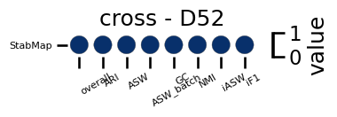

```python
res.plot()
```

## 4. Run everything

One call runs every applicable method and evaluates each:

```
res = mtb.run_all(DATASET, CATEGORY, out_dir="/tmp/cross_all",
                  timeout=4*3600,        # a hung method is recorded, not fatal
                  skip_existing=True)    # resume instead of repeating hours
print(res.failures)                      # ALWAYS check: failures are recorded, not raised
res.plot()
```

Next morning, re-plot **without re-running anything** (`run_all` saved it for you):

```
res = mtb.load_batch("/tmp/cross_all")
res.plot().savefig("compare.png")
```

> WARNING `skip_existing` reuses a method's existing output FILE. Do not combine it with a changed `params=` (you would silently get the old result, so `run_all` refuses it), and after a hard kill delete that method's directory, since a half-written file would be reused as if it had succeeded.

That takes from minutes to hours depending on the scenario, so here we load the stored results of exactly that sweep.

```python
summary = pd.read_csv(RESULTS / "summary_D52.csv")
# clustering metrics, then batch-correction metrics where the design has batches
cols = [c for c in ["method","status","run_sec","ARI","NMI","ASW",
                    "iASW","iF1","ASW_batch","GC"] if c in summary.columns]
summary[cols]
```

|  | method | status | run_sec | ARI | NMI | ASW | iASW | iF1 | ASW_batch | GC |
| --- | --- | --- | --- | --- | --- | --- | --- | --- | --- | --- |
| 0 | Concerto | CHAIN_OK | 8797.8 | 0.6741 | 0.7371 | 0.5175 | 0.5754 | 0.4143 | 0.9414 | 0.8892 |
| 1 | StabMap | CHAIN_OK | 68.6 | 0.6880 | 0.7760 | 0.5569 | 0.6703 | 0.5911 | 0.9241 | 0.9313 |
| 2 | UINMF | CHAIN_OK | 62.8 | 0.6905 | 0.7772 | 0.5668 | 0.5051 | 0.1313 | 0.9353 | 0.9296 |
| 3 | scMDC | CHAIN_OK | 2701.5 | 0.7048 | 0.7791 | 0.6159 | 0.6081 | 0.5153 | 0.8828 | 0.8952 |
| 4 | scMM | CHAIN_OK | 627.8 | 0.3745 | 0.5715 | 0.4990 | 0.5835 | 0.5068 | 0.8310 | 0.8405 |
| 5 | scMoMaT | CHAIN_OK_GRAPH_METHOD | 1022.1 | 0.4738 | 0.6855 | 0.5512 | 0.4773 | 0.4366 | 0.8260 | 0.6140 |
| 6 | sciPENN | CHAIN_OK | 64.2 | 0.6947 | 0.7914 | 0.6062 | 0.7335 | 0.6163 | 0.8814 | 0.9314 |
| 7 | totalVI | CHAIN_OK | 2839.3 | 0.7668 | 0.8030 | 0.5455 | 0.7176 | 0.6038 | 0.9533 | 0.9746 |

### What a failure looks like

`.failures` is the table to check after every sweep, because a method that dies is **recorded, not raised** — the sweep keeps going. Here is a genuine failure: a method given an impossible hyperparameter. Note the sweep still returns normally and the error is in the table.

```python
broken = mtb.run_all(DATASET, CATEGORY, methods=[FAST_METHOD],
                     params={FAST_METHOD: {"epochs": -5}},   # nonsense on purpose
                     out_dir="/tmp/tut_fail", verbose=False)
print("failures:", len(broken.failures))
broken.failures
```

```
failures: 1
```

|  | method | status | error |
| --- | --- | --- | --- |
| 0 | StabMap | FAIL | KeyError: "StabMap does not accept ['epochs']; it accepts []. An empty set means it hardcodes its hyperparameters upstream." |

By contrast, if **nothing at all** can run — a mistyped dataset name, say — that is not a per-method failure, it means the request itself was wrong, so `run_all` raises instead of handing back an empty result that reads as success:

```python
try:
    mtb.run_all("NO_SUCH_DATASET", CATEGORY, out_dir="/tmp/tut_none")
except ValueError as e:
    print("ValueError:", str(e)[:160])
```

```
ValueError: nothing is runnable for dataset='NO_SUCH_DATASET' category='cross'. Inspect mtb.scan('NO_SUCH_DATASET', 'cross') for the full table. First reasons: ["FileNotFou
```

### Reloading a finished sweep

`run_all` saves itself, so the morning after an overnight run you can reopen the results and re-plot **without recomputing anything**:

```python
reloaded = mtb.load_batch("/tmp/tut_fail")      # the sweep we just ran
print(type(reloaded).__name__, "|", len(reloaded), "method(s)")
reloaded.summary[["method", "status"]]
```

```
BatchResult | 1 method(s)
```

|  | method | status |
| --- | --- | --- |
| 0 | StabMap | FAIL |

> **Reading the metric columns.** This benchmark reports two families:
> - **Clustering / dimension reduction** — `ARI`, `NMI`, `ASW`. Always computed.
> - **Batch correction** — `iASW`, `iF1`, `ASW_batch`, `GC`. Computed automatically whenever the dataset has more than one batch; `run_all` derives the batch from which label file each cell came from.

> A blank cell has a specific meaning, and it is worth knowing which:
> - On a **single-batch** dataset (one `cty.csv`, i.e. vertical integration) the batch family does not exist at all — there is nothing to correct.
> - `iASW` / `iF1` measure **isolated labels** — cell types confined to a subset of batches. If every cell type appears in every batch there are none, so both are blank even though the dataset is multi-batch. That is the case on D45.
> - `cLISI` / `iLISI` need a compiled scIB extension that will not load against this machine's GLIBC, and `kBET` needs `rpy2`, which is not installed in the evaluation environment. Those three are environmental, not properties of your data.

## 5. The figure

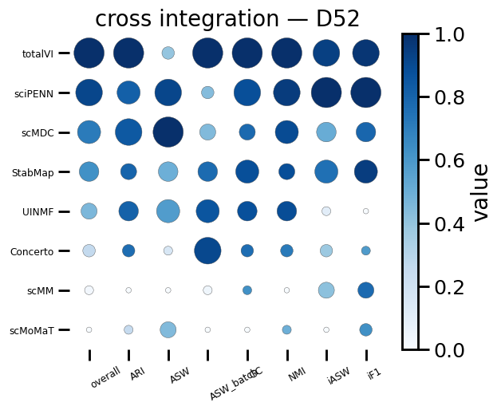

```python
long = pd.read_csv(RESULTS / "long_all_D52.csv")
fig = mtb.plot.bubble(long, title="cross integration — D52")
fig.set_dpi(110)
display(fig)
```

### Summarising across datasets

The bubble chart above compares methods **on this dataset**. To compare them **across** datasets, concatenate the tidy frames and use `plot.bar`, which is the summary the benchmark reports:

```
allf = pd.concat([pd.read_csv(p) for p in RESULTS.glob("long_all_*.csv")])
mtb.plot.bar(allf, title="overall across scenarios")        # every metric
mtb.plot.bar(allf, group="clustering")                      # one family
mtb.plot.bar(allf, group="batch")                           # the other
```

Each bar is a method's mean score over datasets; the dots behind it are its per-dataset scores, so a method that is uniformly good is distinguishable from one that averages well by winning a single dataset.

> The bubble chart encodes **radius = rank** — **rank 1 is the LARGEST bubble** — and **fill = value normalised within the plotted set**, darker being higher. Both are relative to what you plotted. Read the table beside it; with few methods a tiny gap can look decisive.

## 6. Using your OWN dataset

`describe_layout` above already printed the exact filenames for this scenario — **use those, not the role names.** They are not always the same: the `atac_gas` role lives in `atac.h5`, and `atac_peak` lives in `peak.h5`.

```
print(mtb.describe_layout(CATEGORY))   # the authoritative filename list
```

Then the same three calls work unchanged:

```
mtb.scan("MYDATA", category="cross")                     # confirm it is picked up
res = mtb.run_all("MYDATA", "cross", out_dir="out/")     # run everything
res.plot()
```

If `scan` says a method is not runnable, the `reason` column names the missing file — fix that and re-scan. Modality files are HDF5 with the matrix under `matrix/data`; `mtb.io.to_canonical` converts other layouts.

### Note — spatial registration also lives under `cross`

`PASTE`, `PASTE2`, `SPIRAL` and `GPSA` align spatial slices. They take a **directory of `.h5ad` slices** and return **aligned coordinates**, not an embedding, so scIB clustering metrics do not apply to them; they are scored with spatial measures (SCS / PAA) instead.

`scan` separates them automatically — on a non-spatial dataset they are reported as not runnable, with the reason:

```python
mtb.scan("D52", category="cross")[["method", "runnable", "reason"]].tail(4)
```

|  | method | runnable | reason |
| --- | --- | --- | --- |
| 8 | GPSA | False | spatial registration needs >=2 .h5ad slice files; found 0 in /media/disk2/Sichang/scmbench_pkg/data/D52 |
| 9 | PASTE | False | spatial registration needs >=2 .h5ad slice files; found 0 in /media/disk2/Sichang/scmbench_pkg/data/D52 |
| 10 | PASTE2 | False | spatial registration needs >=2 .h5ad slice files; found 0 in /media/disk2/Sichang/scmbench_pkg/data/D52 |
| 11 | SPIRAL | False | spatial registration needs >=2 .h5ad slice files; found 0 in /media/disk2/Sichang/scmbench_pkg/data/D52 |

```python
mtb.scan("D63", category="cross")[["method", "runnable", "output_kind"]].head(4)
```

|  | method | runnable | output_kind |
| --- | --- | --- | --- |
| 0 | GPSA | True | coords |
| 1 | PASTE | True | coords |
| 2 | PASTE2 | True | coords |
| 3 | SPIRAL | True | coords |